# presentation_01

[figure not shown]

BIODYNAMICS: Spatio-temporal dynamics of biotic interactions

[👤](https://ondrejmottl.github.io/)Ondřej Mottl

20.11.2025

## BIODYNAMICS

- 3 years project (2023-2025) [extended to 2026 due to parental leave]
- Funded by Czech Science Foundation (GAČR)

### Objectives

1. Assemble an **interdisciplinary database** that integrates present and past vegetation records with their functional traits and abiotic environments since the Last Glacial Maximum (✅)
2. Identify how **biotic interactions** scale up to form and **maintain biodiversity patterns** at various spatial/temporal/taxonomic scales
3. Improve the capacity to **predict global biodiversity patterns** by including scale-dependent information about biotic interactions (maybe❔)

# VegVault

[figure not shown]

- A global SQLite database linking interdisciplinary **plot-based** vegetation data!
- Links to functional **traits**, **climate** variables, and soil properties
- Built for exploring **biodiversity** dynamics across time & space
- Open Source & Reproducible
- 🔗Learn more: bit.ly/VegVault

[figure not shown]

## VegVault - Overview

~110 GB | 32 tables & 87 variables | 480,000+ Datasets | 13M+ Samples | 110,000+ Taxa | 11M+ Trait values | 8 Abiotic variables

#### Data sources

- 🌿 **Paleoecological records** (Neotoma, FOSSILPOL)
- 🌱 **Contemporary vegetation** (sPlotOpen, BIEN)
- 🌾 **Functional traits** (BIEN, TRY)
- 🌍 **Climate & soil data** (CHELSA, WoSIS)

[figure not shown]

## Key Innovations

1. **Vegetation** data
- Integration of paleo and contemporary data
- Plot-based vegetation records
  - not just species occurrences
  - true negatives!

| Sample ID | Taxa A | Taxa B |
| --- | --- | --- |
| 1 | 🔬🟡 | 🔬🟡🟡🟡 |
| 2 | 🟩🌱🌱🌱 |  |
| 3 | 🟩🌱🌱 | 🟩🌱🌱 |

## Key Innovations

1. **Abiotic** context
- Sample-specific abiotic data
  - mapped to spatio-temporal grids
  - paleo and contemporary
- Selected variables for vegetation studies
  - e.g. temperature, precipitation, soil type, etc.

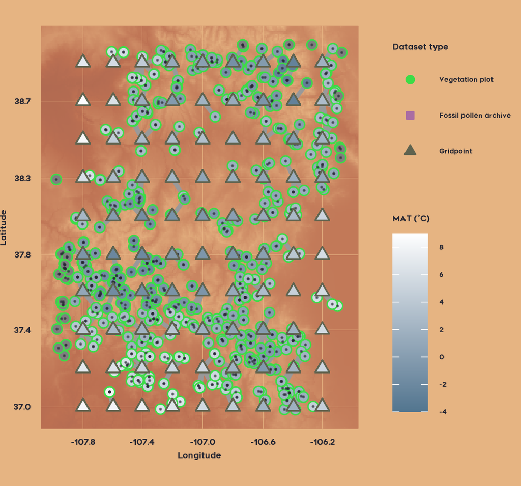

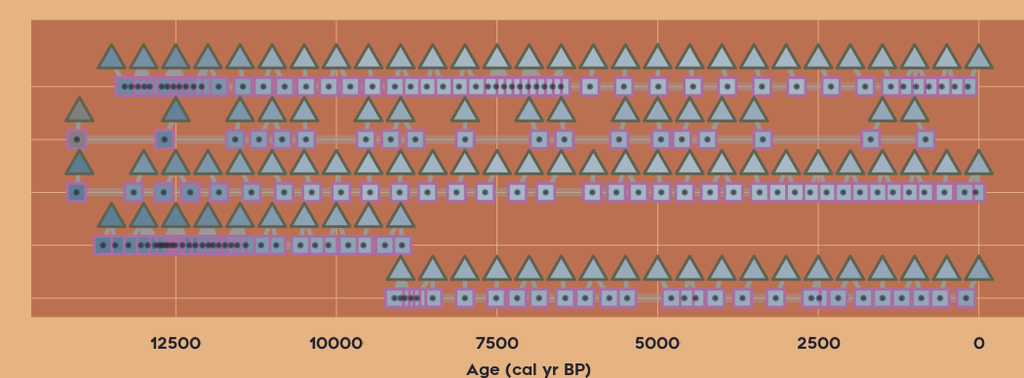

Figures from [VegVault presentation](https://ondrejmottl.github.io/VegVault-Presentation-20250802/)

## Key Innovations

3. **Standardisation**
- Trait domains
  - pooling of traits across sources
  - Following Diaz et al. (2016)
- Taxonomic harmonisation via GBIF backbone and `{taxospace}`📦
  - unified taxonomy across dataset vegetation, fossil pollen and traits

| Trait source | Trait name | Trait Domain |
| --- | --- | --- |
| BIEN | leaf nitrogen content per leaf dry mass | Leaf nitrogen content per unit mass |
| TRY | Leaf nitrogen (N) content per leaf dry mass | Leaf nitrogen content per unit mass |

# Biotic interactions

- Non-random cooccurrences after accounting for environmental filtering
- Can be positive (facilitation) or negative (competition)
- Are scale dependent (?)

## Scales (3 axes)

- **Spatial**
  - “*Biotic interactions from individual sites (local) to whole continents (global)*”
- **Temporal**
  - “*currently observed changes in biodiversity began millennia ago*”
- **Taxonomic**
  - individual taxa
  - phylogenetically cofound groups
  - groups occupying different ecological niches (i.e. Functional Types)

## Research questions

1. Is there a **scale dependence** in the amount of unexplained variation (potentially due to biotic interactions) structuring vegetation?
- Expectation 1 - Strength of biotic interactions decrease with increasing spatial scale
- Expectation 2 - The importance of biotic interaction increase in the periods of large changes (climatic - LGM, anthropogenic - last centuries)
- Expectation 3 - low taxonomic resolution show stronger biotic interactions at larger spatial scales (interaction between spatial and taxonomic scale)

## Research questions

2. Can we improve the **predictive capacity** of biodiversity models by including biotic interactions and historical data?
- Expectation 4 - Including historical data will improve model predictive capacity, especially at large scales
- Expectation 5 - Including biotic interactions will improve model predictive capacity, especially at local scales

# Methodological framework

To address the objectives and research questions, I am developing a large code base with modular and reusable **data-analysis pipelines**

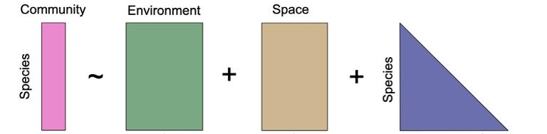

The main methodology is Joined Species Distribution Modelling (JSDM), which allows to infer biotic interactions from species cooccurrence patterns after accounting for environmental filtering

[{sjSDM}](https://cran.r-project.org/web/packages/sjSDM/vignettes/sjSDM_Introduction.html)

## Hierarchical Modelling of Species Communities (HMSC)

[figure not shown]

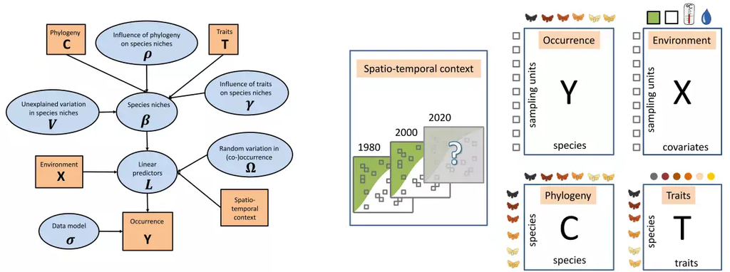

## Methodological framework

[figure not shown]

- using R for all data processing and analyses
- functional programming principles for modularity and reusability
  - everything is a *function*
  - each function is tested and documented ([example](https://ondrejmottl.github.io/BIODYNAMICS-vegetation-cooccurrence/website/Documentation/Functions/add_age_to_samples.html))
  - current code coverage: 95.61%

# “Project” + Pipeline

- to test the individual research questions, I am developing multiple data-analysis *pipelines*
  - each pipeline is a sequence of data processing and analysis steps
  - each pipeline is tailored to a specific research question
- Data and configuration are separated into “project”s
  - each project corresponds to a specific data subset and configuration settings
  - e.g. different regions, temporal resolution, taxonomic resolutions, etc.

## Basic Pipeline

## Basic Pipeline

```
flowchart LR
    Project-.->Pipeline
    subgraph Project
    end
    subgraph Pipeline
    end
```

## Basic Pipeline

```
flowchart LR
    Config-.->Analyses
    subgraph Project
    Config
    end
    subgraph Pipeline
    Analyses
    end
```

## Basic Pipeline

```
flowchart LR
    Config-.->Data
    Config-.->Model
    Config-.->Species_associations
    subgraph Project
        direction TB
        Config
    end
    subgraph Pipeline
        direction LR
        Data-->Model
        Model-->Species_associations
        Species_associations-->Results
    end
```

## Basic Pipeline - Data

```
flowchart LR
    Config-.->VegVault
    Config-.->Model
    Config-.->Species_associations
    subgraph Project
        direction TB
        Config
    end
    subgraph Pipeline
        direction LR
        VegVault-->Model
        Model-->Species_associations
        Species_associations-->Results
    end
```

## Basic Pipeline - Data

```
flowchart LR
    Config-.->VegVault
    Config-.->Model
    Config-.->Species_associations
    subgraph Project
        direction TB
        Config
    end
    subgraph Pipeline
        direction LR
        VegVault-->Model
        Model-->Species_associations
        Species_associations-->Results
    end
```

## Basic Pipeline - Data

```
flowchart LR
    Config-.->VegVault
    Config-.->Model
    Config-.->Species_associations
    subgraph Project
        direction TB
        Config
    end
    subgraph Pipeline
        direction LR
        VegVault-->Data_community
        VegVault-->Data_abiotic
        Data_community-->Model
        Data_abiotic-->Model
        Model-->Species_associations
        Species_associations-->Results
    end
```

## Basic Pipeline - Data

```
flowchart LR
    Config-.->VegVault
    Config-.->Data_interpolated
    Config-.->Model
    Config-.->Species_associations
    subgraph Project
        direction TB
        Config
    end
    subgraph Pipeline
        direction LR
        VegVault-->Data_community
        VegVault-->Data_abiotic
        Data_community-->Data_interpolated
        Data_abiotic-->Data_interpolated
        Data_interpolated-->Model
        Model-->Species_associations
        Species_associations-->Results
    end
```

## Basic Pipeline - Data

```
flowchart LR
    Config-.->VegVault
    Config-.->Classification
    Config-.->Data_interpolated
    Config-.->Model
    Config-.->Species_associations
    subgraph Project
        direction TB
        Config
    end
    subgraph Pipeline
        direction LR
        VegVault-->Data_community
        VegVault-->Data_abiotic
        Data_community-->Classification
        Classification-->Data_harmonised
        Data_abiotic-->Data_interpolated
        Data_harmonised-->Data_interpolated
        Data_interpolated-->Model
        Model-->Species_associations
        Species_associations-->Results
    end
```

## Basic Pipeline - Model

```
flowchart LR
    Config-.->VegVault
    Config-.->Classification
    Config-.->Data_interpolated
    Config-.->Model
    Config-.->Species_associations
    subgraph Project
        direction TB
        Config
    end
    subgraph Pipeline
        direction LR
        VegVault-->Data_community
        VegVault-->Data_abiotic
        Data_community-->Classification
        Classification-->Data_harmonised
        Data_abiotic-->Data_interpolated
        Data_harmonised-->Data_interpolated
        Data_interpolated-->Model
        Model-->Species_associations
        Species_associations-->Results
    end
```

## Basic Pipeline - Model

```
flowchart LR
    Config-.->VegVault
    Config-.->Classification
    Config-.->Data_interpolated
    Config-.->Model
    Config-.->Species_associations
    subgraph Project
        direction TB
        Config
    end
    subgraph Pipeline
        direction LR
        VegVault-->Data_community
        VegVault-->Data_abiotic
        Data_community-->Classification
        Classification-->Data_harmonised
        Data_abiotic-->Data_interpolated
        Data_harmonised-->Data_interpolated
        Data_interpolated-->Model
        Model-->Model_evaluation
        Model_evaluation-->Species_associations
        Species_associations-->Results
    end
```

## Basic Pipeline - Model

```
flowchart LR
    Config-.->VegVault
    Config-.->Classification
    Config-.->Data_interpolated
    Config-.->Model
    Config-.->Species_associations
    subgraph Project
        direction TB
        Config
    end
    subgraph Pipeline
        direction LR
        VegVault-->Data_community
        VegVault-->Data_abiotic
        Data_community-->Classification
        Classification-->Data_harmonised
        Data_abiotic-->Data_interpolated
        Data_harmonised-->Data_interpolated
        Data_interpolated-->Model
        Model-->Model_null
        Model-->Model_full
        Model_null-->Model_evaluation
        Model_full-->Model_evaluation
        Model_evaluation-->Species_associations
        Species_associations-->Results
    end
```

## R implementation

[figure not shown]

- The pipeline is implemented using the `{targets}` R package 📦
  - Each step is a function producing *targets*
  - Each pipeline is constructed using *pipe segments*
    - this allows for modular and reusable code (see later slides)

## Basic Pipeline - {targets}

[interactive chart not shown]

## “Project” == Czech Republic

- simple and small
- used only to test the pipeline
- Settings:
  - only paleo data
  - time extent: 0-5 ka BP
  - abiotic variables: bio1, bio12
  - taxonomic resolution: genus
  - model: 24 chains, 100 samples per chain (total 2400), 2 cross-validation folds

# Model validation and exploration

- convergence diagnostics
- comparison to null model
- variation partitioning
- effect sizes
- species associations

## Convergence diagnostics

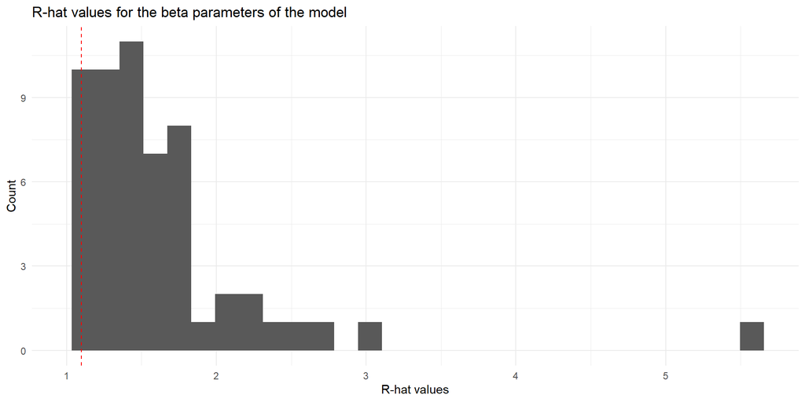

Terrible model - this is just a toy example

## Comparison to null model

- I am selecting model based on the WAIC value
  - there is option to use ThurR2 as well
  - This is done automatically to select NULL or FULL model.
- NULL: 9.004
- FULL: 9.086

Let’s pretend that the FULL model is the one we want to show here.

## Variation partitioning

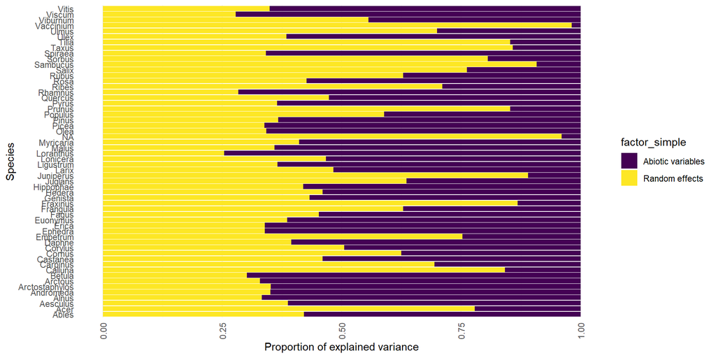

## Variation partitioning

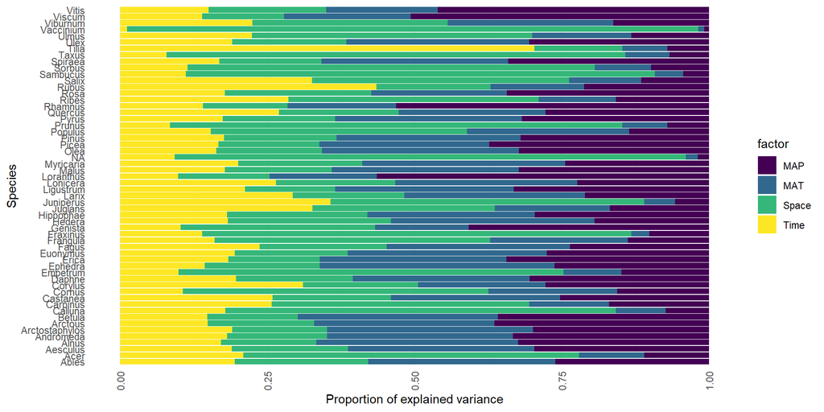

## Effect sizes

*How important are the environmental variables in determining species occurrences?*

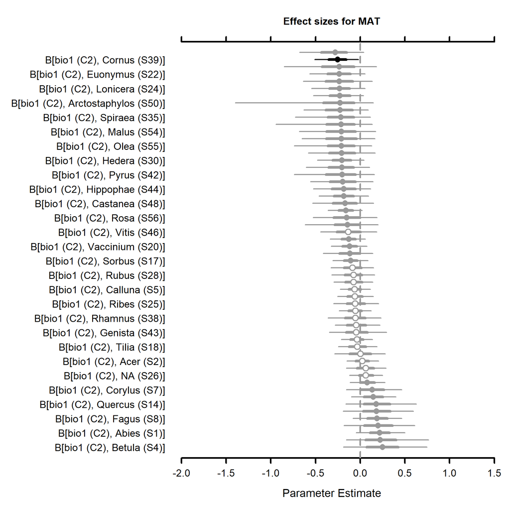

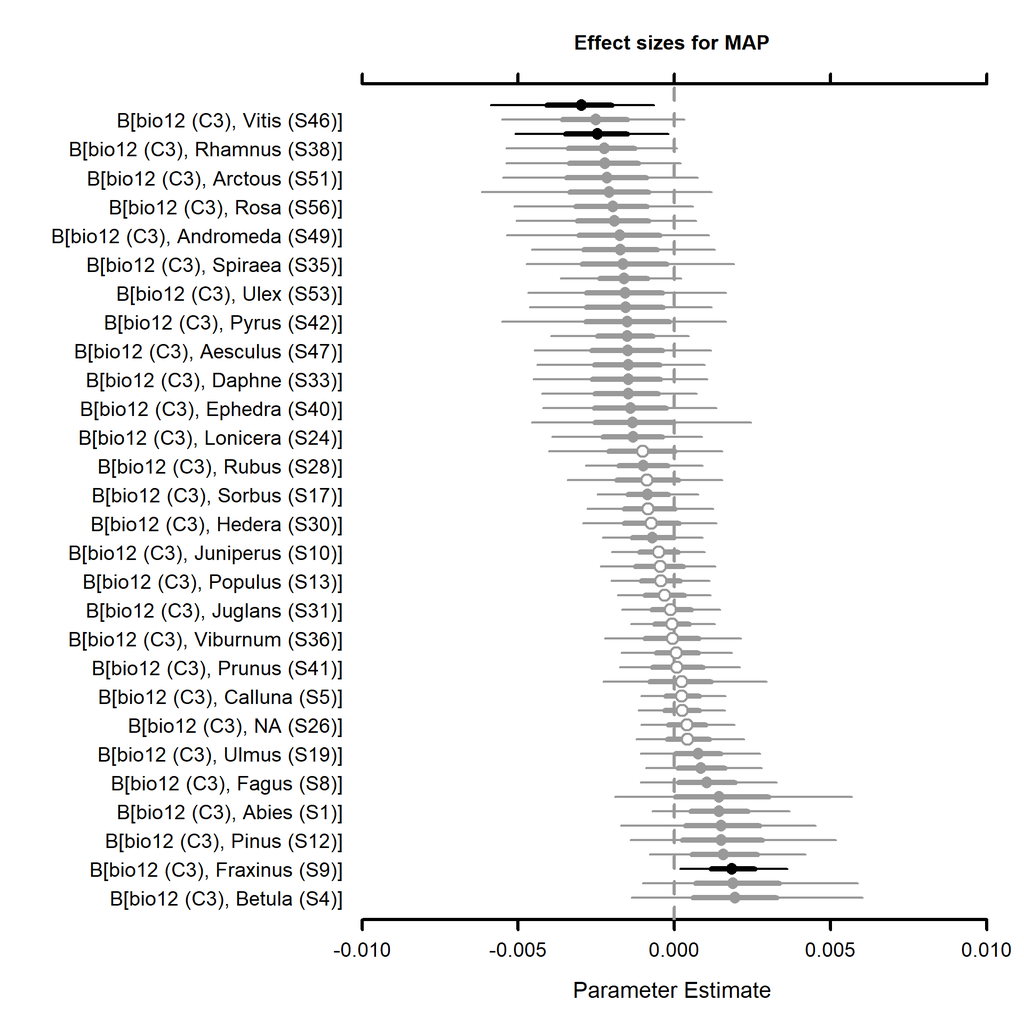

## Species associations

*Which species tend to co-occur more or less often than expected by chance?*

- Based on the residual correlation matrix from the HMSC model

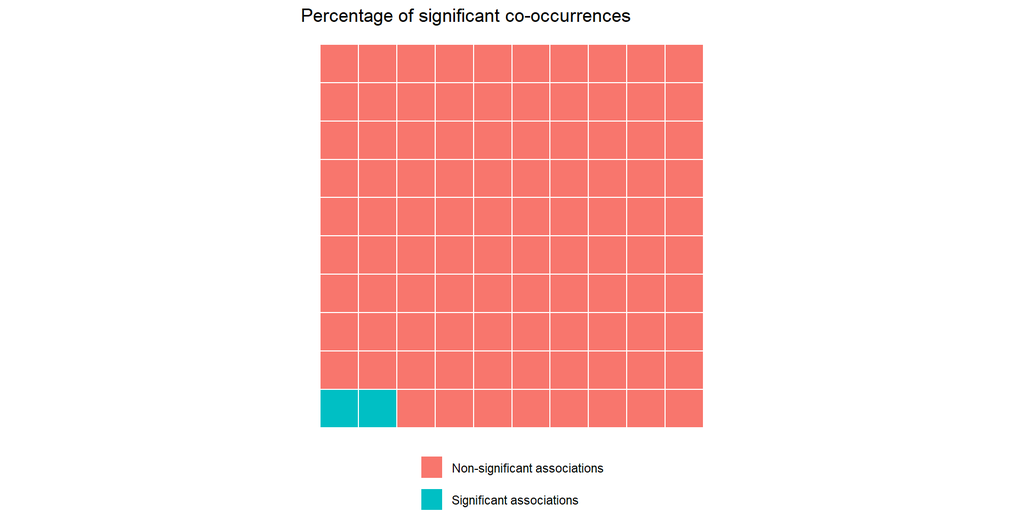

# Biogeography

- We can use the fitted HMSC model to predict species occurrences across space and time
  - e.g., predicting the species colonization patterns after the Last Glacial Maximum (LGM)

## Single taxa plot

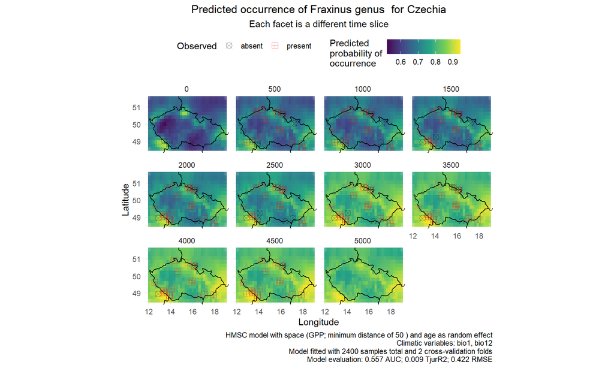

## Diversity through time

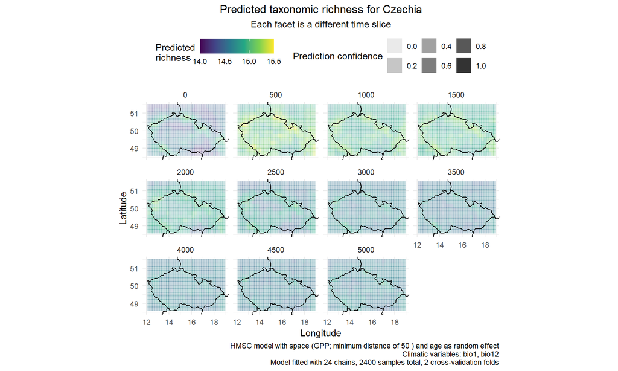

# Time pipeline

```
flowchart LR
    Project-.->Pipeline
    subgraph Project
    end
    subgraph Pipeline
    end
```

## Time pipeline

```
flowchart LR
    Czechia-.->Basic_pipeline
    subgraph Project
    Czechia
    end
    subgraph Pipeline
    Basic_pipeline
    end
```

## Time pipeline

```
flowchart LR
    Czechia-.->Time_pipeline
    subgraph Project
    Czechia
    end
    subgraph Pipeline
    Time_pipeline
    end
```

## Time pipeline

```
flowchart LR
    Config-.->VegVault
    Config-.->Model
    Config-.->Species_associations
    subgraph Project
        direction TB
        Config
    end
    subgraph Pipeline
        direction LR
        VegVault-->Model
        Model-->Species_associations
        Species_associations-->Results
    end
```

## Time pipeline

```
flowchart LR
    Config-.->VegVault
    Config-.->Data_subset
    subgraph Project
        direction TB
        Config
    end
    subgraph Pipeline
        direction LR
        VegVault-->Data_subset
        species_associations_1-->results
        species_associations_2-->results
        species_associations_3-->results
        subgraph Age_slices
            direction LR
            Data_subset-->model_age_1
            Data_subset-->model_age_2
            Data_subset-->model_age_3
            model_age_1-->species_associations_1
            model_age_2-->species_associations_2
            model_age_3-->species_associations_3
        end
end
```

## Time pipeline

```
flowchart LR
    Config-.->VegVault
    Config-.->Classification
    Config-.->Data_interpolated
    Config-.->Data_subset
    subgraph Project
        direction TB
        Config
    end
    subgraph Pipeline
        direction LR
        VegVault-->Data_community
        VegVault-->Data_abiotic
        Data_community-->Classification
        Classification-->Data_harmonised
        Data_abiotic-->Data_interpolated
        Data_harmonised-->Data_interpolated
        Data_interpolated-->Data_subset
        species_associations_1-->results
        species_associations_2-->results
        species_associations_3-->results
        subgraph Age_slices
            direction LR
            Data_subset-->model_age_1
            Data_subset-->model_age_2
            Data_subset-->model_age_3
            model_age_1-->species_associations_1
            model_age_2-->species_associations_2
            model_age_3-->species_associations_3
        end
end
```

## R implementation

[interactive chart not shown]

## Co-occurrences in time slices

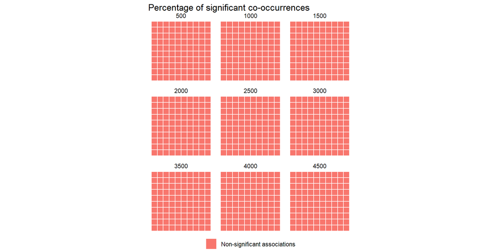

## Co-occurrences in time slices

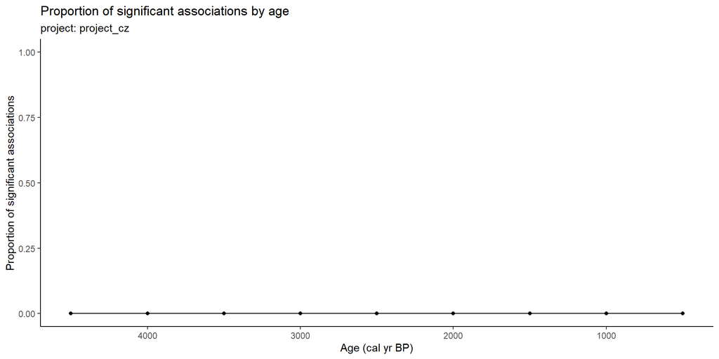

# Next steps

*There is so much more to do! Here are some ideas for next steps.*

## Technical improvements

- Validate the mode with other framework for JSDM
  - {spAbundance} or {spOccupancy}
- Filter out climatic variables before fitting (based on correlation)
- Speed everything up
  - Set up HPC at Metacentrum
  - use scalable joint Species Distribution Model ({sjSDM})?

## Methodological improvements

- Move beyond presence-absence data
  - use the hurdle model
- Implement functional traits in the model
- Implement the functional types classification
- Get more nuanced understanding of species associations by analysing co-occurrences as bipartite networks (food webs)

## Co-occurrences as bipartite networks

- Co-occurrence networks can be seen as bipartite networks
- first layer: individual plots
- second layer: taxa

## Co-occurrences as bipartite networks

Example of time slice 2000 years BP:

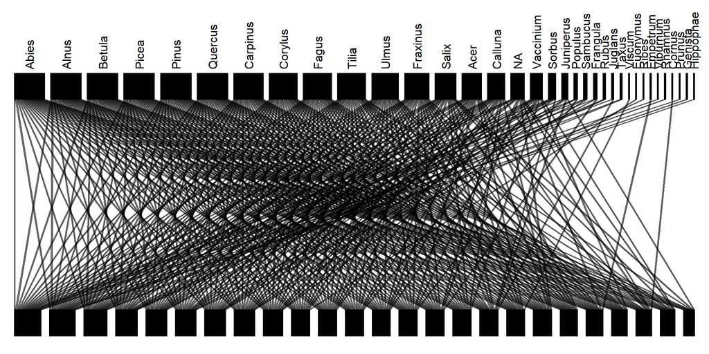

## Co-occurrences as bipartite networks

Calculate network-level metrics for each network:

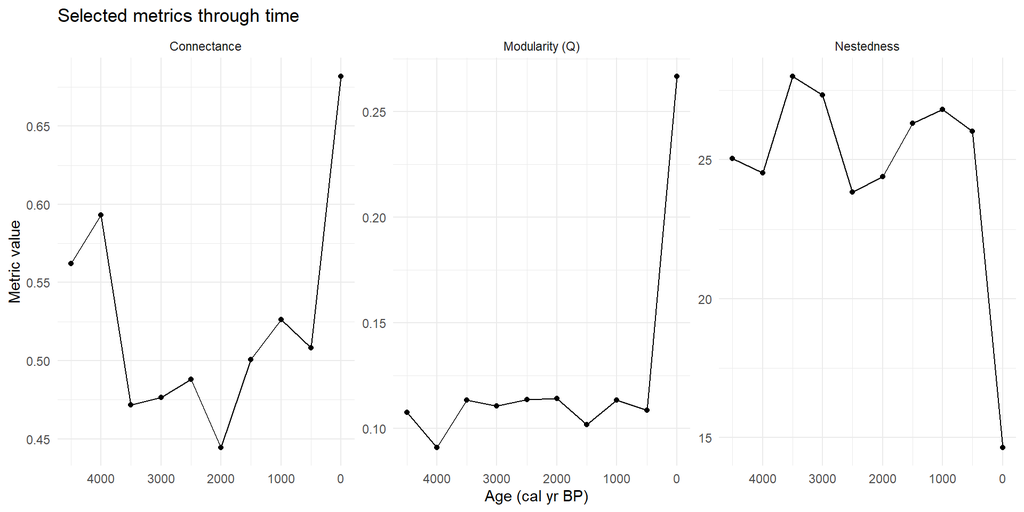

# Open and public

Everything shown here is fully open and reproducible! You can find the whole project( inlcuding code and materials for this presentation) on GitHub:

[😸 Code on GitHub](https://github.com/OndrejMottl/BIODYNAMICS-vegetation-cooccurrence)

[figure not shown]

## Research questions

1. Is there a **scale dependence** in the amount of unexplained variation (potentially due to biotic interactions) structuring vegetation?
2. Can we improve the **predictive capacity** of biodiversity models by including biotic interactions and historical data?